# Following on from Ward et al.

Owen Petchey

9 February 2016

# Some time series and predictions

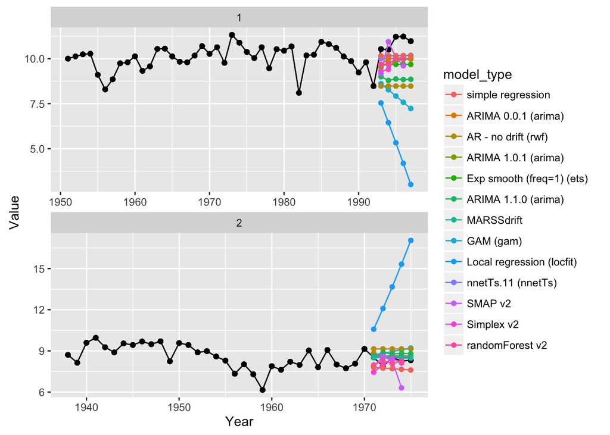

Without local regression:

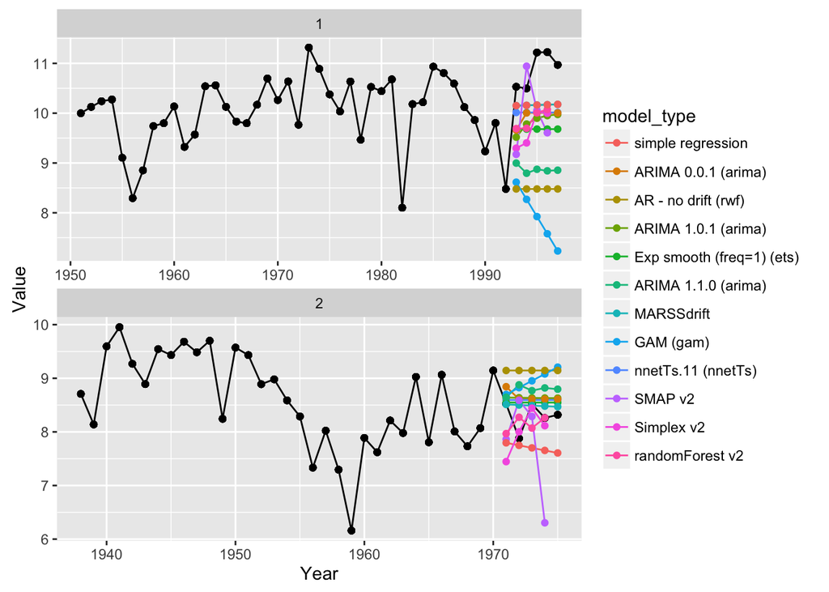

# Are any models good (or bad) across all time series?

Recreate the original figure, which shows the average ASE of each model, for each model tested against every time series. This asks whether any of the models are generally (i.e., across all time series) good (or bad):

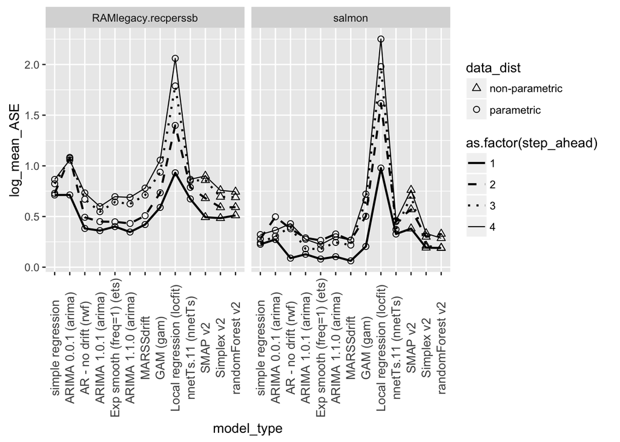

And the figure from the original paper:

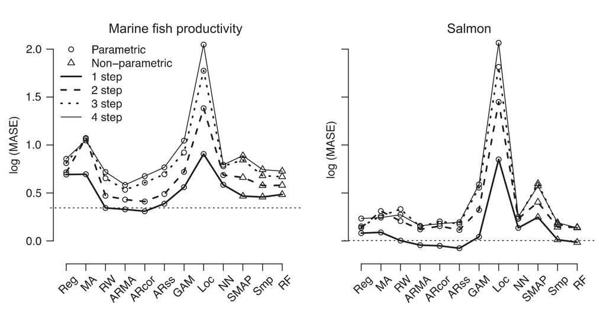

# How good is the best model for each time series?

Find best (minimum mean ASE) model for each time series:

Overlay on the original figure:

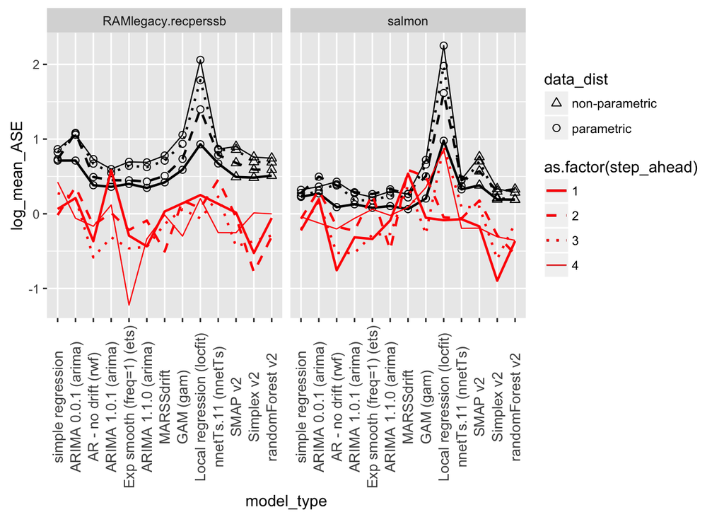

Its not really so useful to make this comparison, as the results pretty much have to be as they are (better prediction by the best model for each time series, than for all models for all time series). It may be somewhat interesting to see that the MASE is often now less than 1 (0 on log scale), as MASE = 1 is what one expects as for a random walk model for long time series, though note that also the random walk model often has MASE less than 1, probably just by chance.

Could compare the MASE of the best model (not including random walk) to that of the random walk MASE.

Though the bigger issue that needs resolution is using the test data (the last five data points) for model selection. The test data should be reserved for model validation (e.g., input-output transormation validation) only.

How many times is each model the best?

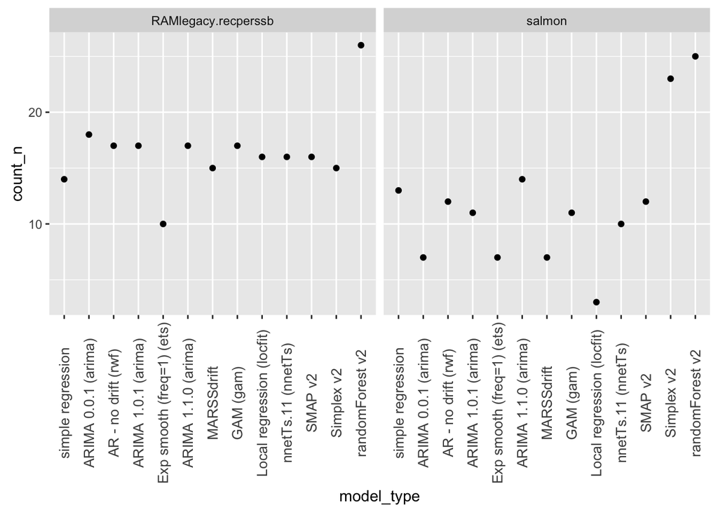

# Length of time series

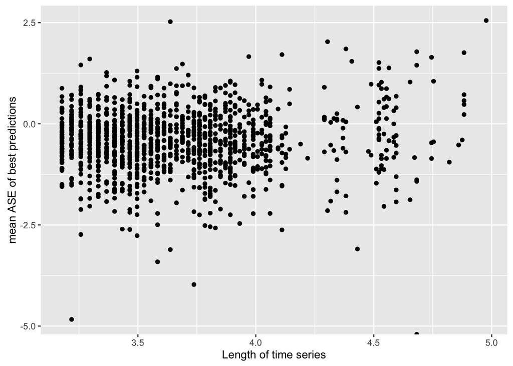